# Multiple Regression Review

February 3, 2021

## Data Context

- Most college courses conclude with anonymous student evaluations.
- Evaluations as an indicator of course quality and teaching effectiveness is often criticized.
- Evaluation scores may reflect the influence of non-teaching related characteristics, such as the physical appearance.

These data contain observations on 463 courses at the University of Texas Austin, with 23 variables recorded in the data:

- information about the course
- information about the professor
- information about number of students
- information about the “attractiveness” rating of the professor

## Simple Linear Regression Review

We can model the relationship between a professor’s evaluation score (`score`) and their average attractiveness score (`bty_avg`) with a simple linear regression!

- Scores for average beauty can range from 0 to 10
- Evaluation scores can range from 1 to 5

**What are the model conditions we need to check for a simple linear regression?**

## Visualizing SLR

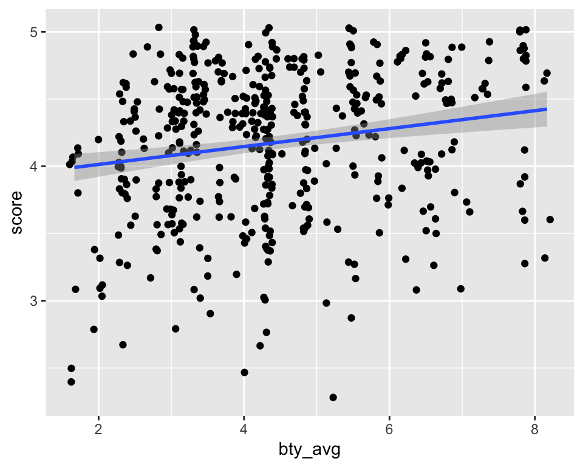

```r
evals %>%
  ggplot(aes(x = bty_avg, y = score)) +
  geom_jitter() +
  geom_smooth(method = "lm")
```

## Fitting a SLR Model

```r
model1 <- lm(score ~ bty_avg, data = evals)

get_regression_table(model1)
```

```
## # A tibble: 2 x 7
##   term      estimate std_error statistic p_value lower_ci upper_ci
##   <chr>        <dbl>     <dbl>     <dbl>   <dbl>    <dbl>    <dbl>
## 1 intercept    3.88      0.076     51.0        0    3.73     4.03
## 2 bty_avg      0.067     0.016      4.09       0    0.035    0.099
```

**How would we interpret the intercept and slope from this model?**

## Multiple Linear Regression

In multiple regression we include **multiple** explanatory variables, which can be categorical or quantitative.

- Categorical variables lead to different regression lines
- Quantitative variables lead to different planes in dataspace

**In this course, we will mainly stick to regression models with one quantitative and one categorical explanatory variables.**

## Visualizing Multiple Linear Regression

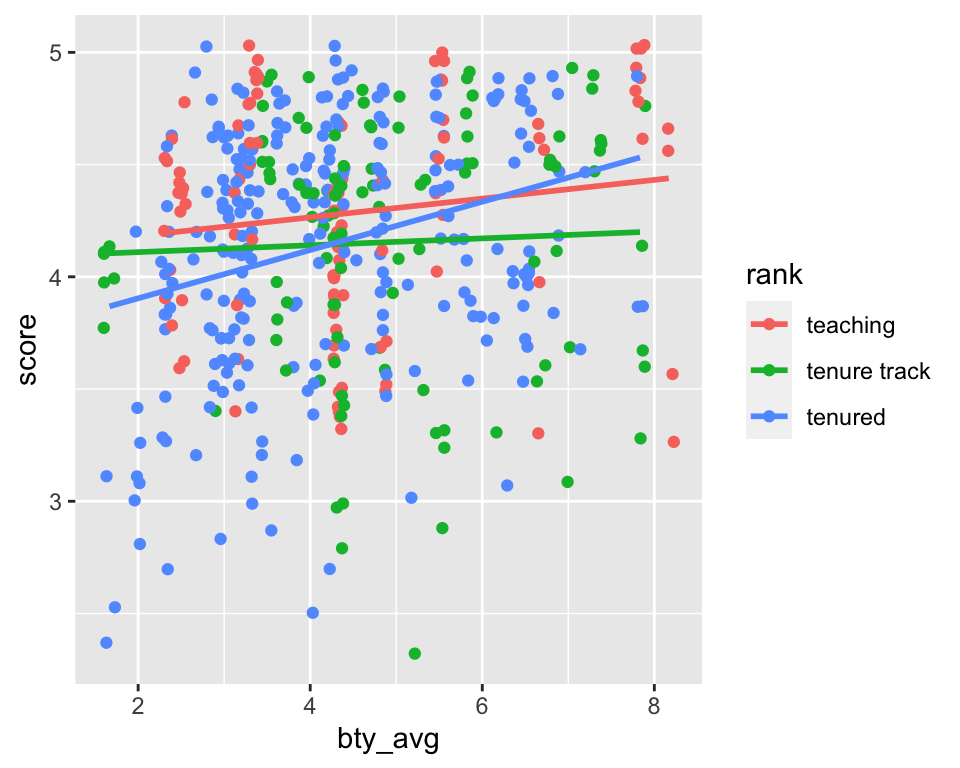

```r
evals %>%
  ggplot(aes(x = bty_avg, y = score, color = rank)) +
  geom_jitter() +
  geom_smooth(method = "lm", se = FALSE)
```

## Modeling Options

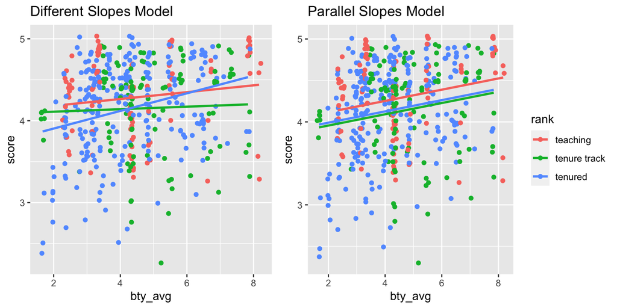

## Fitting a Parallel Slopes Model

```r
model_parallel <- lm(score ~ bty_avg + rank, data = evals)

coef(model_parallel) %>%
  tidy()
```

```
## # A tibble: 4 x 2
##   names                  x
##   <chr>              <dbl>
## 1 (Intercept)       3.98
## 2 bty_avg           0.0678
## 3 ranktenure track -0.161
## 4 ranktenured      -0.126
```

## Interpreting a Parallel Slopes Model

```
## # A tibble: 4 x 2
##   names                  x
##   <chr>              <dbl>
## 1 (Intercept)       3.98
## 2 bty_avg           0.0678
## 3 ranktenure track -0.161
## 4 ranktenured      -0.126
```

- Who does the `intercept` correspond to?
- What does the estimate labeled `ranktenure track` correspond to?
- What does the estimate labeled `ranktenured` correspond to?

## Calculating the Different Lines

[output not shown]

## Writing the Complete Parallel Slopes Model

\[ \widehat{score} = 3.98 - 0.161 \cdot 1_{\text{is tenure track}} - 0.126 \cdot 1_{\text{is tenured}} \\ + 0.068 \cdot \text{bty_avg} \] where

\[ 1_{\text{is tenure track}} = \begin{cases} 1, & \text{ if professor is tenure track} \\ 0, & \text{ if professor is not tenure track} \end{cases} \] and

\[ 1_{\text{is tenured}} = \begin{cases} 1, & \text{ if professor is tenured} \\ 0, & \text{ if professor is not tenured} \end{cases} \]

## Writing Individual Regression Lines

- Teaching Professors: \[ \widehat{score} = 3.98 + 0.068 \cdot bty\_avg \]
- Tenure Track Professors: \[ \widehat{score} = 3.819 + 0.068 \cdot bty\_avg \]
- Tenured Professors: \[ \widehat{score} = 3.854 + 0.068 \cdot bty\_avg \]

## Fitting a Different Slopes Model

```r
model_diff <- lm(score ~ bty_avg + rank + bty_avg:rank, data = evals)

coef(model_diff) %>%
  tidy()
```

```
## # A tibble: 6 x 2
##   names                          x
##   <chr>                      <dbl>
## 1 (Intercept)               4.10
## 2 bty_avg                   0.0417
## 3 ranktenure track         -0.0188
## 4 ranktenured              -0.409
## 5 bty_avg:ranktenure track -0.0264
## 6 bty_avg:ranktenured       0.0659
```

## Interpreting a Different Slopes Model

```r
coef(model_diff) %>%
  tidy()
```

```
## # A tibble: 6 x 2
##   names                          x
##   <chr>                      <dbl>
## 1 (Intercept)               4.10
## 2 bty_avg                   0.0417
## 3 ranktenure track         -0.0188
## 4 ranktenured              -0.409
## 5 bty_avg:ranktenure track -0.0264
## 6 bty_avg:ranktenured       0.0659
```

## Calculating the Different Lines

[output not shown]

\[ 1_{\text{is tenure track}} = \begin{cases} 1, & \text{ if professor is tenure track} \\ 0, & \text{ if professor is not tenure track} \end{cases} \] and

\[ 1_{\text{is tenured}} = \begin{cases} 1, & \text{ if professor is tenured} \\ 0, & \text{ if professor is not tenured} \end{cases} \]

## Your Turn

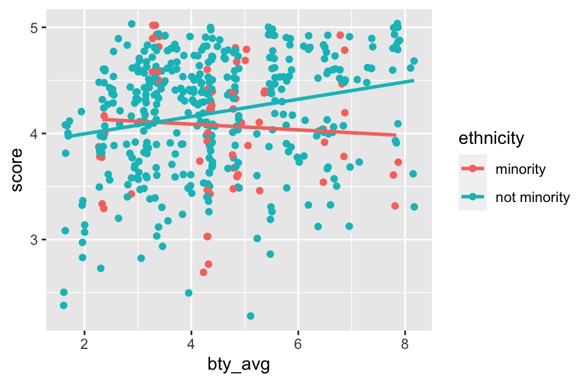

```r
evals %>%
  ggplot(aes(x = bty_avg, y = score, color = ethnicity)) +
  geom_jitter() +
  geom_smooth(method = "lm", se = FALSE)
```

**Does it seem reasonable to use a different slopes model?**

```r
model_ethnicity <- lm(score ~ bty_avg + ethnicity + bty_avg:ethnicity,
                      data = evals)

coef(model_ethnicity) %>%
  tidy()
```

```
## # A tibble: 4 x 2
##   names                               x
##   <chr>                           <dbl>
## 1 (Intercept)                    4.19
## 2 bty_avg                       -0.0269
## 3 ethnicitynot minority         -0.362
## 4 bty_avg:ethnicitynot minority  0.108
```